# Week 6: Project 2 - Data Transformation

Md Asadul Islam

2024-10-13

```r
library(dplyr)
library(ggplot2)
```

### Wide Dataset 1 - FL - Housing Insecurity Indicators Dataset

This dataset of potential indicators to assess people’s risk of losing their homes in Florida.The author intended to use the dataset to understand which groups of people are at higher risk of lossing their homes in Florida.The dataset and analysis is as done below:

```r
# Reading the dataset
housing_dt <- read.csv("C:\\Users\\HP\\Downloads\\data_1-FL.csv", sep=",", )

# View the columns
colnames(housing_dt)
```

```
##   [1] "geoid"
##   [2] "geoid_year"
##   [3] "state"
##   [4] "county"
##   [5] "state_fips_code"
##   [6] "county_fips_code"
##   [7] "b19083_001e"
##   [8] "b19083_001m"
##   [9] "economic_distress_pop_agg"
##  [10] "economic_distress_simple_agg"
##  [11] "investment_areas"
##  [12] "opzone"
##  [13] "b23025_002e"
##  [14] "b23025_002m"
##  [15] "b23025_004e"
```

[output cut: 370 more lines]

```r
# Inspect the dataset
str(housing_dt)
```

```
## 'data.frame':    1605 obs. of  385 variables:
##  $ geoid                                                                : num  1.2e+10 1.2e+10 1.2e+10 1.2e+10 1.2e+10 ...
##  $ geoid_year                                                           : int  2020 2020 2020 2020 2020 2020 2020 2020 2020 2020 ...
##  $ state                                                                : int  12 12 12 12 12 12 12 12 12 12 ...
##  $ county                                                               : int  1 1 1 1 1 1 1 1 1 1 ...
##  $ state_fips_code                                                      : int  12 12 12 12 12 12 12 12 12 12 ...
##  $ county_fips_code                                                     : int  1 1 1 1 1 1 1 1 1 1 ...
##  $ b19083_001e                                                          : num  0.393 0.547 0.364 0.366 0.569 ...
##  $ b19083_001m                                                          : num  0.0724 0.0649 0.0878 0.0894 0.0634 0.0479 0.0615 0.0825 0.0898 0.0697 ...
##  $ economic_distress_pop_agg                                            : chr  "YES" "YES" "YES" "YES" ...
##  $ economic_distress_simple_agg                                         : chr  "YES" "YES" "YES" "YES" ...
##  $ investment_areas                                                     : chr  "YES" "YES" "YES" "YES" ...
##  $ opzone                                                               : int  1 0 0 0 0 0 0 0 1 0 ...
##  $ b23025_002e                                                          : int  2958 1431 962 2413 1145 3851 2295 1266 556 3119 ...
##  $ b23025_002m                                                          : int  768 326 215 351 274 654 355 254 219 453 ...
```

[output cut: 86 more lines]

```r
summary(housing_dt)
```

```
##      geoid             geoid_year       state        county
##  Min.   :1.200e+10   Min.   :2020   Min.   :12   Min.   :  1.00
##  1st Qu.:1.202e+10   1st Qu.:2020   1st Qu.:12   1st Qu.: 19.00
##  Median :1.207e+10   Median :2020   Median :12   Median : 71.00
##  Mean   :1.206e+10   Mean   :2020   Mean   :12   Mean   : 60.85
##  3rd Qu.:1.210e+10   3rd Qu.:2020   3rd Qu.:12   3rd Qu.: 97.00
##  Max.   :1.213e+10   Max.   :2020   Max.   :12   Max.   :133.00
##
##  state_fips_code county_fips_code  b19083_001e          b19083_001m
##  Min.   :12      Min.   :  1.00   Min.   :-666666666   Min.   :-222222222
##  1st Qu.:12      1st Qu.: 19.00   1st Qu.:         0   1st Qu.:         0
##  Median :12      Median : 71.00   Median :         0   Median :         0
##  Mean   :12      Mean   : 60.85   Mean   :  -7476635   Mean   :  -2492212
##  3rd Qu.:12      3rd Qu.: 97.00   3rd Qu.:         0   3rd Qu.:         0
##  Max.   :12      Max.   :133.00   Max.   :         1   Max.   :         0
##
##  economic_distress_pop_agg economic_distress_simple_agg investment_areas
##  Length:1605               Length:1605                  Length:1605
##  Class :character          Class :character             Class :character
##  Mode  :character          Mode  :character             Mode  :character
##
##
##
##
##      opzone        b23025_002e     b23025_002m      b23025_004e
##  Min.   :0.0000   Min.   :    0   Min.   :   7.0   Min.   :    0
##  1st Qu.:0.0000   1st Qu.: 1272   1st Qu.: 274.0   1st Qu.: 1176
##  Median :0.0000   Median : 1980   Median : 379.0   Median : 1866
##  Mean   :0.1059   Mean   : 2105   Mean   : 422.2   Mean   : 1981
##  3rd Qu.:0.0000   3rd Qu.: 2769   3rd Qu.: 526.0   3rd Qu.: 2604
##  Max.   :1.0000   Max.   :10724   Max.   :1816.0   Max.   :10223
##
##   b23025_004m      b23025_005e     b23025_005m      b23025_006e
##  Min.   :   7.0   Min.   :  0.0   Min.   :  3.00   Min.   :   0.00
##  1st Qu.: 261.0   1st Qu.: 37.0   1st Qu.: 39.00   1st Qu.:   0.00
##  Median : 366.0   Median : 81.0   Median : 68.00   Median :   0.00
##  Mean   : 404.9   Mean   :106.4   Mean   : 87.43   Mean   :  17.99
##  3rd Qu.: 509.0   3rd Qu.:143.0   3rd Qu.:109.00   3rd Qu.:   0.00
##  Max.   :1684.0   Max.   :915.0   Max.   :740.00   Max.   :1608.00
##
```

[output cut: 953 more lines]

```
##  Min.   :-666666666   Min.   :-333333333   Min.   :-666666666
##  1st Qu.:      1008   1st Qu.:       114   1st Qu.:       828
##  Median :      1291   Median :       169   Median :      1163
##  Mean   :  -8306022   Mean   :  -3184286   Mean   : -20351818
##  3rd Qu.:      1614   3rd Qu.:       257   3rd Qu.:      1576
##  Max.   :      4001   Max.   :      1493   Max.   :      4001
##
##  s2503_c03_024m       s2503_c05_024e       s2503_c05_024m
##  Min.   :-333333333   Min.   :-666666666   Min.   :-333333333
##  1st Qu.:       154   1st Qu.:      1107   1st Qu.:       101
##  Median :       241   Median :      1404   Median :       167
##  Mean   :  -7614793   Mean   : -43612282   Mean   : -16614504
##  3rd Qu.:       376   3rd Qu.:      1756   3rd Qu.:       295
##  Max.   :      2473   Max.   :      3501   Max.   :      2043
##
```

```r
#Clean data
demographic_summary <- housing_dt %>%
  summarize(
    avg_income = mean(`b19083_001e`, na.rm = TRUE),
    avg_poverty_level = mean(`s1701_c03_001e`, na.rm = TRUE),
    avg_employment = mean(`b23025_002e`, na.rm = TRUE),
    avg_unemployment = mean(`b23025_005e`, na.rm = TRUE)
  )

print(demographic_summary)
```

```
##   avg_income avg_poverty_level avg_employment avg_unemployment
## 1   -7476635          -7476622        2105.18         106.3801
```

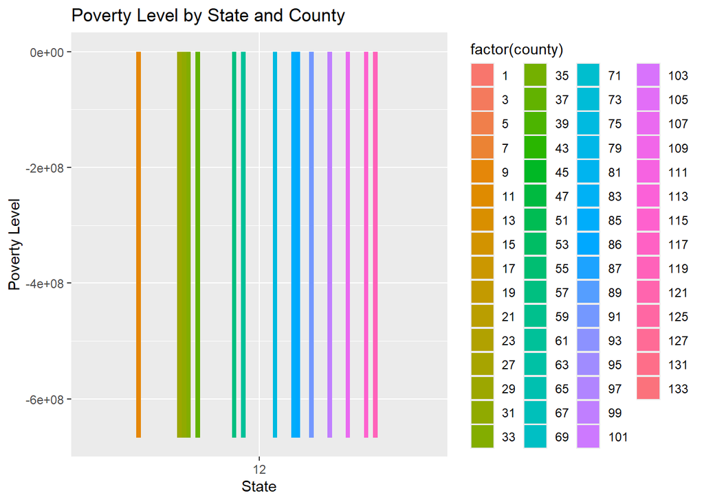

```r
# Do the analysis
ggplot(housing_dt, aes(x = factor(state), y = `s1701_c03_001e`, fill = factor(county))) +
  geom_bar(stat = "identity", position = "dodge") +
  labs(title = "Poverty Level by State and County", x = "State", y = "Poverty Level")
```

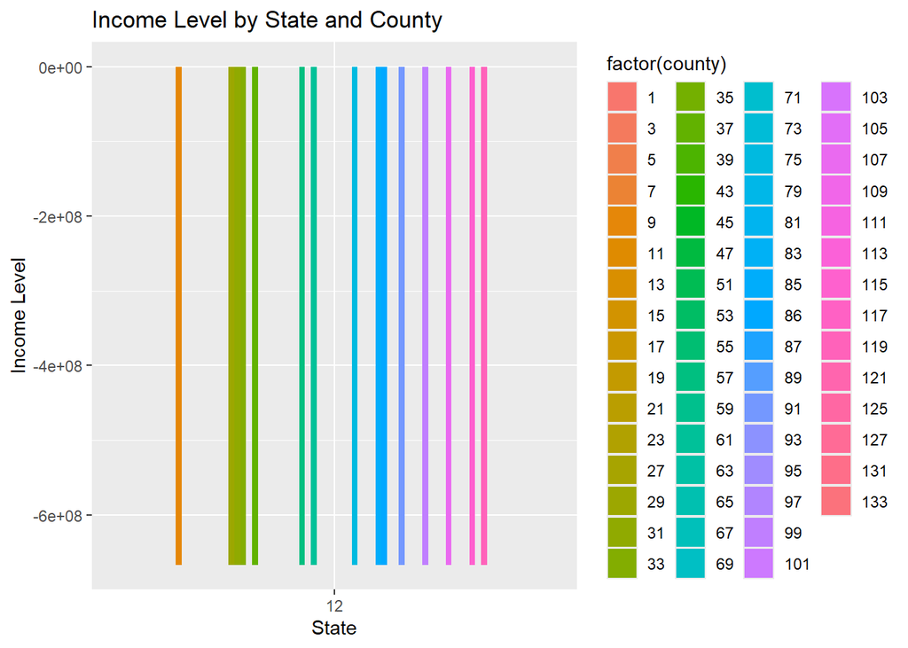

```r
ggplot(housing_dt, aes(x = factor(state), y = `b19083_001e`, fill = factor(county))) +
  geom_bar(stat = "identity", position = "dodge") +
  labs(title = "Income Level by State and County", x = "State", y = "Income Level")
```

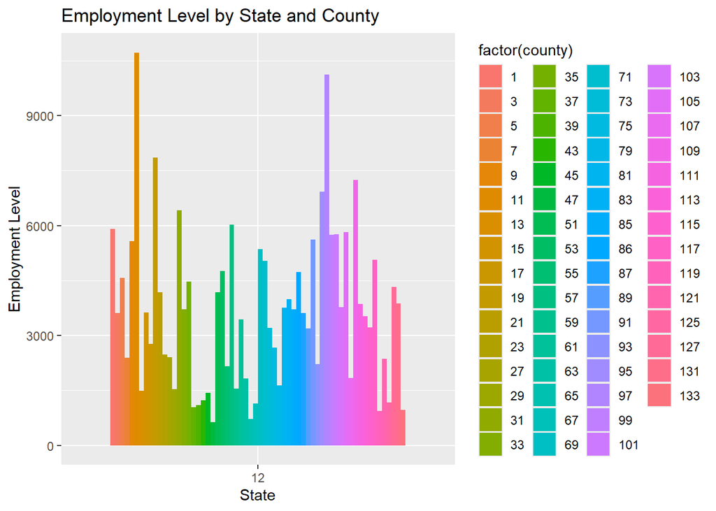

```r
ggplot(housing_dt, aes(x = factor(state), y = `b23025_002e`, fill = factor(county))) +
  geom_bar(stat = "identity", position = "dodge") +
  labs(title = "Employment Level by State and County", x = "State", y = "Employment Level")
```

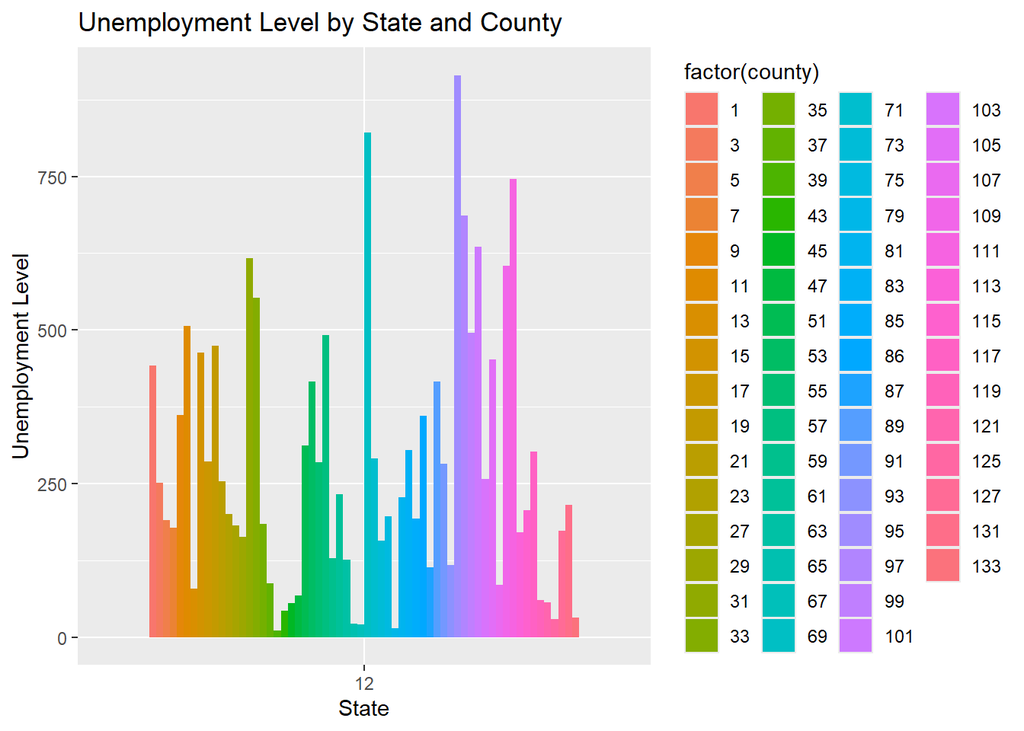

```r
ggplot(housing_dt, aes(x = factor(state), y = `b23025_005e`, fill = factor(county))) +
  geom_bar(stat = "identity", position = "dodge") +
  labs(title = "Unemployment Level by State and County", x = "State", y = "Unemployment Level")
```

### Analysis and Conclusion for Dataset 1

Descriptive Statistics

The dataset includes the following columns:

1. geoid: Geographic identifier.
2. geoid_year: Year of the geographic data.
3. state: State code.
4. county: County code.
5. state_fips_code: Federal Information Processing Standards code for the state.
6. county_fips_code: Federal Information Processing Standards code for the county.
7. Various socio-economic indicators such as b19083_001e, b23025_002e, s1701_c03_001e, s1903_c03_001e, and s2701_c03_001e representing different economic, employment, poverty, and health statistics.

Key Observations

1. geoid and geoid_year:

The geographic identifier ranges from 12,000,000,000 to over 12,020,000,000, representing different geographic entities. The year is consistently 2020, indicating that all data points are from the same year.

2. State and County Codes:

The state code and state FIPS code both have a minimum value of 12, which corresponds to Florida. County codes range from 1 to 133, representing various counties within the state.

3.Economic and Employment Indicators:

b23025_002e (Labor Force): Minimum values are zero, suggesting that some counties may have reported no active labor force. b23025_004e (Employment): Similarly shows minimum values of zero, indicating no employment in some areas. b23025_005e (Unemployment): Minimum values of zero but first quartile (Q1) values are much higher, indicating that unemployment is prevalent in certain counties.

4. Poverty Indicators:

s1701_c03_001e (Poverty Rate): Contains negative values which are likely errors or placeholders for missing data (e.g., -666666666). Other poverty indicators like s1701_c03_002e to s1701_c03_021e follow a similar pattern with erroneous minimum values.

5. Health Indicators:

s2701_c03_001e (Health Insurance Coverage): Minimum values are negative, indicating potential data entry issues.

### Dataset 2 - Hotel Booking

```r
# Reading the dataset
hotel_dt <- read.csv("C:\\Users\\HP\\Downloads\\archive\\hotel_bookings.csv", sep=",", )

# View the columns
colnames(hotel_dt)
```

```
##  [1] "hotel"                          "is_canceled"
##  [3] "lead_time"                      "arrival_date_year"
##  [5] "arrival_date_month"             "arrival_date_week_number"
##  [7] "arrival_date_day_of_month"      "stays_in_weekend_nights"
##  [9] "stays_in_week_nights"           "adults"
## [11] "children"                       "babies"
## [13] "meal"                           "country"
## [15] "market_segment"                 "distribution_channel"
## [17] "is_repeated_guest"              "previous_cancellations"
## [19] "previous_bookings_not_canceled" "reserved_room_type"
## [21] "assigned_room_type"             "booking_changes"
## [23] "deposit_type"                   "agent"
## [25] "company"                        "days_in_waiting_list"
## [27] "customer_type"                  "adr"
## [29] "required_car_parking_spaces"    "total_of_special_requests"
## [31] "reservation_status"             "reservation_status_date"
```

```r
# Inspect the dataset
str(hotel_dt)
```

```
## 'data.frame':    119390 obs. of  32 variables:
##  $ hotel                         : chr  "Resort Hotel" "Resort Hotel" "Resort Hotel" "Resort Hotel" ...
##  $ is_canceled                   : int  0 0 0 0 0 0 0 0 1 1 ...
##  $ lead_time                     : int  342 737 7 13 14 14 0 9 85 75 ...
##  $ arrival_date_year             : int  2015 2015 2015 2015 2015 2015 2015 2015 2015 2015 ...
##  $ arrival_date_month            : chr  "July" "July" "July" "July" ...
##  $ arrival_date_week_number      : int  27 27 27 27 27 27 27 27 27 27 ...
##  $ arrival_date_day_of_month     : int  1 1 1 1 1 1 1 1 1 1 ...
##  $ stays_in_weekend_nights       : int  0 0 0 0 0 0 0 0 0 0 ...
##  $ stays_in_week_nights          : int  0 0 1 1 2 2 2 2 3 3 ...
##  $ adults                        : int  2 2 1 1 2 2 2 2 2 2 ...
##  $ children                      : int  0 0 0 0 0 0 0 0 0 0 ...
##  $ babies                        : int  0 0 0 0 0 0 0 0 0 0 ...
##  $ meal                          : chr  "BB" "BB" "BB" "BB" ...
##  $ country                       : chr  "PRT" "PRT" "GBR" "GBR" ...
```

[output cut: 18 more lines]

```r
summary(hotel_dt)
```

```
##     hotel            is_canceled       lead_time   arrival_date_year
##  Length:119390      Min.   :0.0000   Min.   :  0   Min.   :2015
##  Class :character   1st Qu.:0.0000   1st Qu.: 18   1st Qu.:2016
##  Mode  :character   Median :0.0000   Median : 69   Median :2016
##                     Mean   :0.3704   Mean   :104   Mean   :2016
##                     3rd Qu.:1.0000   3rd Qu.:160   3rd Qu.:2017
##                     Max.   :1.0000   Max.   :737   Max.   :2017
##
##  arrival_date_month arrival_date_week_number arrival_date_day_of_month
##  Length:119390      Min.   : 1.00            Min.   : 1.0
##  Class :character   1st Qu.:16.00            1st Qu.: 8.0
##  Mode  :character   Median :28.00            Median :16.0
##                     Mean   :27.17            Mean   :15.8
##                     3rd Qu.:38.00            3rd Qu.:23.0
##                     Max.   :53.00            Max.   :31.0
##
##  stays_in_weekend_nights stays_in_week_nights     adults
##  Min.   : 0.0000         Min.   : 0.0         Min.   : 0.000
##  1st Qu.: 0.0000         1st Qu.: 1.0         1st Qu.: 2.000
##  Median : 1.0000         Median : 2.0         Median : 2.000
##  Mean   : 0.9276         Mean   : 2.5         Mean   : 1.856
##  3rd Qu.: 2.0000         3rd Qu.: 3.0         3rd Qu.: 2.000
##  Max.   :19.0000         Max.   :50.0         Max.   :55.000
##
##     children           babies              meal             country
##  Min.   : 0.0000   Min.   : 0.000000   Length:119390      Length:119390
##  1st Qu.: 0.0000   1st Qu.: 0.000000   Class :character   Class :character
##  Median : 0.0000   Median : 0.000000   Mode  :character   Mode  :character
##  Mean   : 0.1039   Mean   : 0.007949
##  3rd Qu.: 0.0000   3rd Qu.: 0.000000
##  Max.   :10.0000   Max.   :10.000000
##  NA's   :4
##  market_segment     distribution_channel is_repeated_guest
##  Length:119390      Length:119390        Min.   :0.00000
##  Class :character   Class :character     1st Qu.:0.00000
##  Mode  :character   Mode  :character     Median :0.00000
##                                          Mean   :0.03191
##                                          3rd Qu.:0.00000
##                                          Max.   :1.00000
##
```

[output cut: 25 more lines]

```
##  Min.   :0.00000             Min.   :0.0000            Length:119390
##  1st Qu.:0.00000             1st Qu.:0.0000            Class :character
##  Median :0.00000             Median :0.0000            Mode  :character
##  Mean   :0.06252             Mean   :0.5714
##  3rd Qu.:0.00000             3rd Qu.:1.0000
##  Max.   :8.00000             Max.   :5.0000
##
##  reservation_status_date
##  Length:119390
##  Class :character
##  Mode  :character
##
##
##
##
```

```r
# Clean data
missing_values <- colSums(is.na(hotel_dt))
print(missing_values)
```

```
##                          hotel                    is_canceled
##                              0                              0
##                      lead_time              arrival_date_year
##                              0                              0
##             arrival_date_month       arrival_date_week_number
##                              0                              0
##      arrival_date_day_of_month        stays_in_weekend_nights
##                              0                              0
##           stays_in_week_nights                         adults
##                              0                              0
##                       children                         babies
##                              4                              0
##                           meal                        country
##                              0                              0
##                 market_segment           distribution_channel
##                              0                              0
##              is_repeated_guest         previous_cancellations
##                              0                              0
## previous_bookings_not_canceled             reserved_room_type
##                              0                              0
##             assigned_room_type                booking_changes
##                              0                              0
##                   deposit_type                          agent
##                              0                              0
##                        company           days_in_waiting_list
##                              0                              0
##                  customer_type                            adr
##                              0                              0
##    required_car_parking_spaces      total_of_special_requests
##                              0                              0
##             reservation_status        reservation_status_date
##                              0                              0
```

```r
# Drop rows with missing values in critical columns (like 'adr' or 'hotel')
hotel_data_clean <- hotel_dt %>%
  filter(!is.na(adr), !is.na(hotel))

# Convert categorical variables
hotel_data_clean$arrival_date_month <- factor(hotel_data_clean$arrival_date_month,
                                               levels = month.abb,
                                               labels = month.name)

# Create a total stay variable
hotel_data_clean$total_stay <- hotel_data_clean$stays_in_weekend_nights + hotel_data_clean$stays_in_week_nights

# Best Time to Book
monthly_analysis <- hotel_data_clean %>%
  group_by(arrival_date_month) %>%
  summarise(avg_adr = mean(adr, na.rm = TRUE),
            cancel_rate = mean(is_canceled, na.rm = TRUE)) %>%
  arrange(arrival_date_month)

# Print monthly analysis
print(monthly_analysis)
```

```
## # A tibble: 2 × 3
##   arrival_date_month avg_adr cancel_rate
##   <fct>                <dbl>       <dbl>
## 1 May                   109.       0.397
## 2 <NA>                  101.       0.368
```

```
## `geom_line()`: Each group consists of only one observation.
## ℹ Do you need to adjust the group aesthetic?
## `geom_line()`: Each group consists of only one observation.
## ℹ Do you need to adjust the group aesthetic?
```

[figure not shown]

```r
# Plot the Average Daily Rate (ADR) and Cancellation Rate by Month
ggplot(monthly_analysis, aes(x = arrival_date_month)) +
  geom_line(aes(y = avg_adr, color = "Average Daily Rate"), size = 1) +
  geom_line(aes(y = cancel_rate * 100, color = "Cancellation Rate"), size = 1) +
  scale_y_continuous(sec.axis = sec_axis(~./100, name = "Cancellation Rate (%)")) +
  labs(title = "ADR and Cancellation Rate by Month", y = "ADR", x = "Month") +
  theme_minimal()
```

```r
# Optimal Length of Stay
stay_analysis <- hotel_data_clean %>%
  group_by(total_stay) %>%
  summarise(avg_adr = mean(adr, na.rm = TRUE),
            cancel_rate = mean(is_canceled, na.rm = TRUE))

# Print stay analysis
print(stay_analysis)
```

```
## # A tibble: 45 × 3
##    total_stay avg_adr cancel_rate
##         <int>   <dbl>       <dbl>
##  1          0     0        0.0490
##  2          1    94.7      0.251
##  3          2    97.7      0.440
##  4          3   105.       0.419
##  5          4   105.       0.366
##  6          5   113.       0.342
##  7          6   120.       0.398
##  8          7   103.       0.343
##  9          8   114.       0.380
## 10          9   115.       0.372
## # ℹ 35 more rows
```

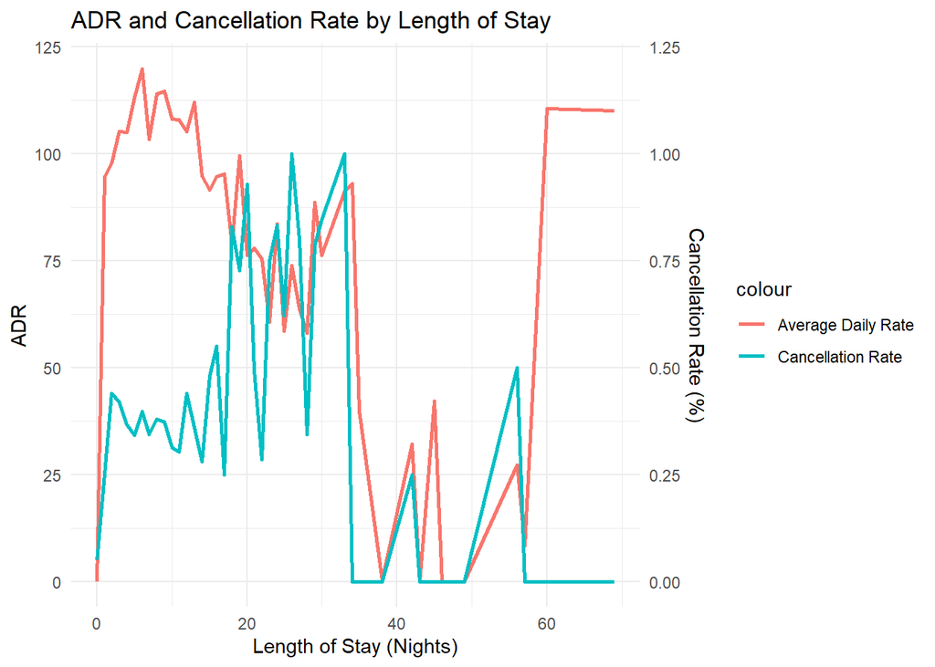

```r
# Plot the Average Daily Rate (ADR) and Cancellation Rate by Length of Stay
ggplot(stay_analysis, aes(x = total_stay)) +
  geom_line(aes(y = avg_adr, color = "Average Daily Rate"), size = 1) +
  geom_line(aes(y = cancel_rate * 100, color = "Cancellation Rate"), size = 1) +
  scale_y_continuous(sec.axis = sec_axis(~./100, name = "Cancellation Rate (%)")) +
  labs(title = "ADR and Cancellation Rate by Length of Stay", y = "ADR", x = "Length of Stay (Nights)") +
  theme_minimal()
```

```r
# Define formula
model <- glm(is_canceled ~ lead_time + total_stay + total_of_special_requests,
             data = hotel_data_clean,
             family = binomial)

# Summary of the model
summary(model)
```

```
##
## Call:
## glm(formula = is_canceled ~ lead_time + total_stay + total_of_special_requests,
##     family = binomial, data = hotel_data_clean)
##
## Coefficients:
##                             Estimate Std. Error z value Pr(>|z|)
## (Intercept)               -0.7805035  0.0125146  -62.37   <2e-16 ***
## lead_time                  0.0056953  0.0000643   88.58   <2e-16 ***
## total_stay                -0.0056516  0.0025460   -2.22   0.0264 *
## total_of_special_requests -0.6889429  0.0096145  -71.66   <2e-16 ***
## ---
## Signif. codes:  0 '***' 0.001 '**' 0.01 '*' 0.05 '.' 0.1 ' ' 1
##
## (Dispersion parameter for binomial family taken to be 1)
##
##     Null deviance: 157398  on 119389  degrees of freedom
## Residual deviance: 141050  on 119386  degrees of freedom
## AIC: 141058
##
## Number of Fisher Scoring iterations: 4
```

### Data Analysis for Dataset 2

1. Intercept:

The intercept coefficient is −0.7805 −0.7805 with a highly significant p-value (<2𝑒−16 <2e−16). This value represents the log odds of cancellation when all predictors are at zero. In practical terms, it serves as a baseline for the model.

2. Lead Time:

The coefficient for lead time is 0.0057 with a very significant p-value (<2𝑒−16<2e−16). This positive coefficient indicates that as the lead time (the number of days between booking and arrival) increases, the odds of cancellation also increase. Specifically, for every additional day in lead time, the odds of cancellation increase by approximately 0.57%.

3. Total Stay:

The coefficient for total stay is −0.0057 with a significant p-value (0.0264). This negative coefficient implies that longer stays are associated with a decreased likelihood of cancellation. Specifically, for each additional night of stay, the odds of cancellation decrease by about 0.57%.

4. Total of Special Requests:

The coefficient for total of special requests is −0.6889 with a highly significant p-value (<2𝑒−16<2e−16). This large negative coefficient suggests that if a guest makes special requests, the odds of cancellation decrease significantly. For each additional special request made, the odds of cancellation decrease by approximately 49.8% 49.8%. This indicates that guests who request special services or amenities are more likely to follow through with their reservations.

5. Model Fit:

The model has a null deviance of 157398 and a residual deviance of 141050. The reduction in deviance indicates that the predictors included in the model improve its fit compared to a model with no predictors.The AIC (Akaike Information Criterion) value of 141058 can be used for model comparison, with lower values indicating a better fit relative to other models.

### Conclusion for Dataset 2

Lead time is a crucial factor in predicting cancellations, with longer lead times correlating to higher cancellation rates. This suggests that booking strategies might consider encouraging shorter lead times to secure confirmed reservations.

Total stay plays a significant role, as longer stays correlate with reduced cancellation rates. This finding may inform pricing strategies or promotions aimed at encouraging longer stays.

Special requests are a strong predictor of booking commitment. Hotels could leverage this information by encouraging guests to make special requests, which may enhance customer loyalty and reduce cancellations.

### DataSet 3 - World Population

```r
# Reading the dataset
population_dt <- read.csv("C:\\Users\\HP\\Downloads\\world_population.csv", sep=",", )

# View the columns
colnames(population_dt)
```

```
##  [1] "Rank"                        "CCA3"
##  [3] "Country.Territory"           "Capital"
##  [5] "Continent"                   "X2022.Population"
##  [7] "X2020.Population"            "X2015.Population"
##  [9] "X2010.Population"            "X2000.Population"
## [11] "X1990.Population"            "X1980.Population"
## [13] "X1970.Population"            "Area..km.."
## [15] "Density..per.km.."           "Growth.Rate"
## [17] "World.Population.Percentage"
```

```r
# Inspect the dataset
str(population_dt)
```

```
## 'data.frame':    234 obs. of  17 variables:
##  $ Rank                       : int  36 138 34 213 203 42 224 201 33 140 ...
##  $ CCA3                       : chr  "AFG" "ALB" "DZA" "ASM" ...
##  $ Country.Territory          : chr  "Afghanistan" "Albania" "Algeria" "American Samoa" ...
##  $ Capital                    : chr  "Kabul" "Tirana" "Algiers" "Pago Pago" ...
##  $ Continent                  : chr  "Asia" "Europe" "Africa" "Oceania" ...
##  $ X2022.Population           : int  41128771 2842321 44903225 44273 79824 35588987 15857 93763 45510318 2780469 ...
##  $ X2020.Population           : int  38972230 2866849 43451666 46189 77700 33428485 15585 92664 45036032 2805608 ...
##  $ X2015.Population           : int  33753499 2882481 39543154 51368 71746 28127721 14525 89941 43257065 2878595 ...
##  $ X2010.Population           : int  28189672 2913399 35856344 54849 71519 23364185 13172 85695 41100123 2946293 ...
##  $ X2000.Population           : int  19542982 3182021 30774621 58230 66097 16394062 11047 75055 37070774 3168523 ...
##  $ X1990.Population           : int  10694796 3295066 25518074 47818 53569 11828638 8316 63328 32637657 3556539 ...
##  $ X1980.Population           : int  12486631 2941651 18739378 32886 35611 8330047 6560 64888 28024803 3135123 ...
##  $ X1970.Population           : int  10752971 2324731 13795915 27075 19860 6029700 6283 64516 23842803 2534377 ...
##  $ Area..km..                 : int  652230 28748 2381741 199 468 1246700 91 442 2780400 29743 ...
##  $ Density..per.km..          : num  63.1 98.9 18.9 222.5 170.6 ...
##  $ Growth.Rate                : num  1.026 0.996 1.016 0.983 1.01 ...
##  $ World.Population.Percentage: num  0.52 0.04 0.56 0 0 0.45 0 0 0.57 0.03 ...
```

```r
# Clean the dataset
missing_values <- colSums(is.na(population_dt))

#summary
summary(population_dt)
```

```
##       Rank            CCA3           Country.Territory    Capital
##  Min.   :  1.00   Length:234         Length:234         Length:234
##  1st Qu.: 59.25   Class :character   Class :character   Class :character
##  Median :117.50   Mode  :character   Mode  :character   Mode  :character
##  Mean   :117.50
##  3rd Qu.:175.75
##  Max.   :234.00
##   Continent         X2022.Population    X2020.Population    X2015.Population
##  Length:234         Min.   :5.100e+02   Min.   :5.200e+02   Min.   :5.640e+02
##  Class :character   1st Qu.:4.197e+05   1st Qu.:4.153e+05   1st Qu.:4.047e+05
##  Mode  :character   Median :5.560e+06   Median :5.493e+06   Median :5.307e+06
##                     Mean   :3.407e+07   Mean   :3.350e+07   Mean   :3.173e+07
##                     3rd Qu.:2.248e+07   3rd Qu.:2.145e+07   3rd Qu.:1.973e+07
##                     Max.   :1.426e+09   Max.   :1.425e+09   Max.   :1.394e+09
##  X2010.Population    X2000.Population    X1990.Population
##  Min.   :5.960e+02   Min.   :6.510e+02   Min.   :7.000e+02
##  1st Qu.:3.931e+05   1st Qu.:3.272e+05   1st Qu.:2.641e+05
##  Median :4.943e+06   Median :4.293e+06   Median :3.825e+06
##  Mean   :2.985e+07   Mean   :2.627e+07   Mean   :2.271e+07
##  3rd Qu.:1.916e+07   3rd Qu.:1.576e+07   3rd Qu.:1.187e+07
##  Max.   :1.348e+09   Max.   :1.264e+09   Max.   :1.154e+09
##  X1980.Population    X1970.Population      Area..km..       Density..per.km..
##  Min.   :      733   Min.   :      752   Min.   :       1   Min.   :    0.026
##  1st Qu.:   229614   1st Qu.:   155997   1st Qu.:    2650   1st Qu.:   38.418
##  Median :  3141146   Median :  2604830   Median :   81200   Median :   95.347
##  Mean   : 18984617   Mean   : 15786909   Mean   :  581449   Mean   :  452.127
##  3rd Qu.:  9826054   3rd Qu.:  8817329   3rd Qu.:  430426   3rd Qu.:  238.933
##  Max.   :982372466   Max.   :822534450   Max.   :17098242   Max.   :23172.267
##   Growth.Rate    World.Population.Percentage
##  Min.   :0.912   Min.   : 0.0000
##  1st Qu.:1.002   1st Qu.: 0.0100
##  Median :1.008   Median : 0.0700
##  Mean   :1.010   Mean   : 0.4271
##  3rd Qu.:1.017   3rd Qu.: 0.2800
##  Max.   :1.069   Max.   :17.8800
```

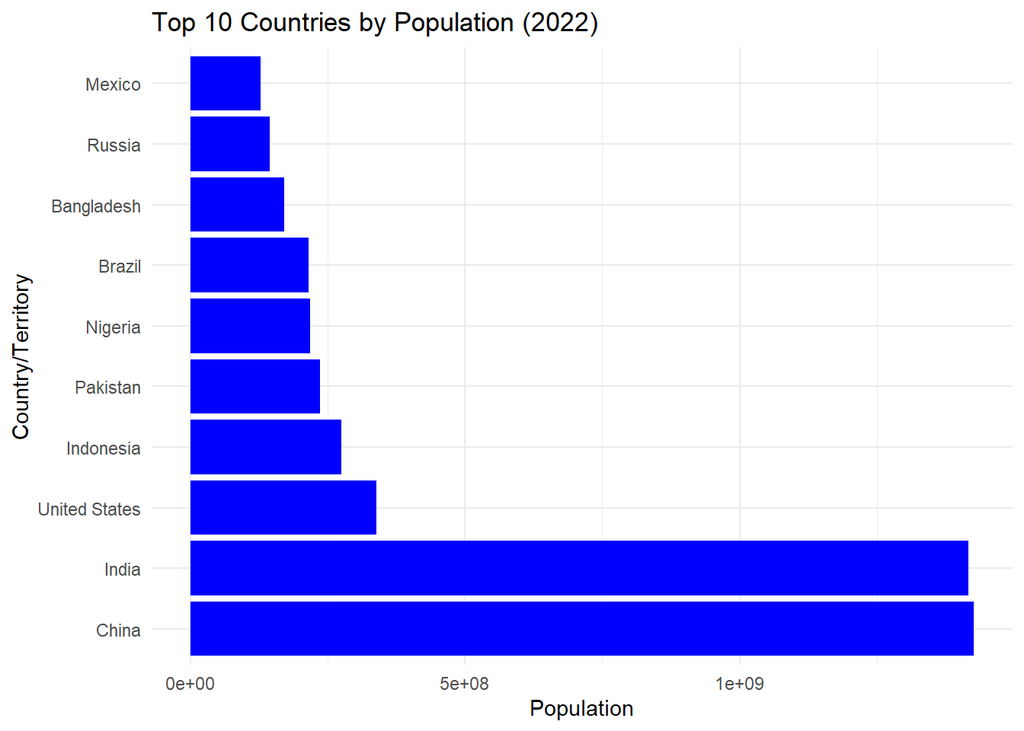

```r
# Remove duplicates
population_dt <- population_dt %>% distinct()

# Rename columns for easier access
population_dt <- population_dt %>%
  rename(
    Population_2022 = X2022.Population,
    Population_2020 = X2020.Population,
    Population_2015 = X2015.Population,
    Population_2010 = X2010.Population,
    Population_2000 = X2000.Population,
    Population_1990 = X1990.Population,
    Population_1980 = X1980.Population,
    Population_1970 = X1970.Population,
    Area_km2 = Area..km..
  )
# Calculate growth from 2010 to 2022
population_dt <- population_dt %>%
  mutate(Growth_2010_2022 = Population_2022 - Population_2010)


# Calculate population density
population_dt <- population_dt %>%
  mutate(Density = Population_2022 / Area_km2)

# Bar chart of the top 10 countries by population
top_10 <- population_dt %>%
  arrange(desc(Population_2022)) %>%
  head(10)

ggplot(top_10, aes(x = reorder(Country.Territory, -Population_2022), y = Population_2022)) +
  geom_bar(stat = "identity", fill = "blue") +
  labs(title = "Top 10 Countries by Population (2022)", x = "Country/Territory", y = "Population") +
  theme_minimal() +
  coord_flip()
```

```r
# Show summary statistics
print(summary)
```

[output not shown]

```r
# Print missing values
print(missing_values)
```

```
##                        Rank                        CCA3
##                           0                           0
##           Country.Territory                     Capital
##                           0                           0
##                   Continent            X2022.Population
##                           0                           0
##            X2020.Population            X2015.Population
##                           0                           0
##            X2010.Population            X2000.Population
##                           0                           0
##            X1990.Population            X1980.Population
##                           0                           0
##            X1970.Population                  Area..km..
##                           0                           0
##           Density..per.km..                 Growth.Rate
##                           0                           0
## World.Population.Percentage
##                           0
```

### Conclusion

…